# AMP - Frequently asked questions

Understanding distributions for RCT analysis

Michael Barber

August 25th, 2017

# 1 FAQ introduction

This is the FAQ for the Analyst Mentorship Program ran by Michael Barber and the Agricultural research team. Here you will find two types of question (each in the appropriate section); questions about the AMP and statistics mentorship in general, and technical questions relating to the application of code/statistical concepts. You can use the list on the left to easily navigate to where you would like. Generally, if you are already in AMP you will want the technical FAQ, if you are not in the AMP you will want the other FAQ.

# 2 AMP and statistical mentorship FAQ

## 2.1 I’m a manager looking for a quick primer on statistics, do you have anything for me?

## 2.2 Can I join AMP?

# 3 Technical FAQ

## 3.6 I want to analyse time-series data, can you help?

Ocassionally we might also want to test time series data to compare trends in two groups. Let’s simulate some time series data to analyse. In this simulation we will be tracking the average spend from groups of farmers. We have already summarised the data from the individual level to the district level and calculated the associated StDevs.

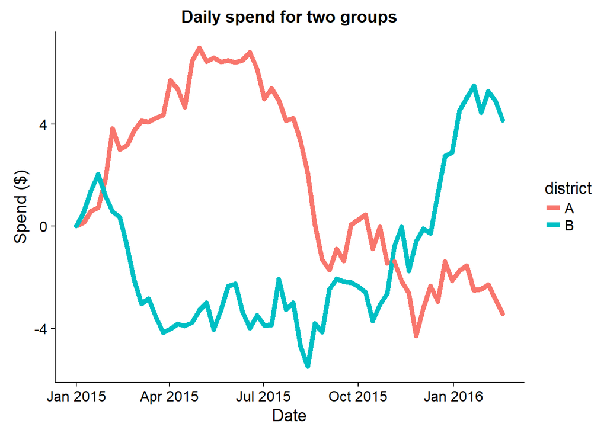

```r
set.seed(1121)
dates = seq(as.Date("2015/1/1"), by = "week", length.out = 60)
df1 = data.frame( vals= diffinv(rnorm(59)), errors = rnorm(60),Date=dates, district="A")
df2 = data.frame( vals= diffinv(rnorm(59)), errors=rnorm(60), Date=dates, district="B")

df = rbind(df1,df2)

ggplot(df, aes(x=Date, y=vals, group=district, color=district)) + geom_line(size=2) +  geom_point() + xlab("Date") + ylab("Spend ($)") + ggtitle("Daily spend for two groups")
```

Now we want to know whether there are any significant difference between these groups of farmers. Our first step is to add error bars to our plots:

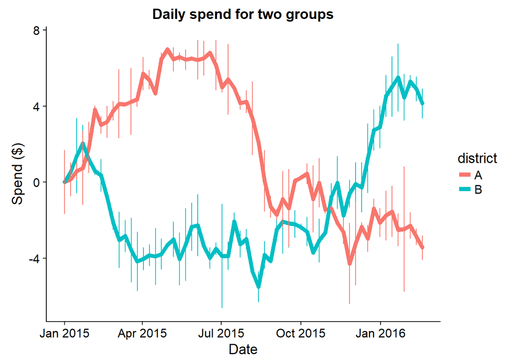

```r
ggplot(df, aes(x=Date, y=vals, group=district, color=district)) + geom_line(size=2) +  geom_point() + xlab("Date") + ylab("Spend ($)") + ggtitle("Daily spend for two groups") +   geom_errorbar(aes(ymin=vals-errors, ymax=vals+errors), width=.2,
                 position=position_dodge(0.05))
```

So we can see that some of our district A points are above some of our district B points. But how do we know if this is random chance fluctuations or significant deviations?

```r
#lets first add a new marker for when A is above B

df$marker <- "N"
#get index where A > B
indx = which(subset(df, district=="A")$vals > subset(df, district=="B")$vals)
df[indx,]$marker = "Y"

table(subset(df, district=="A")$marker)
```

```
##
##  N  Y
## 20 40
```

We then assign a value for success, here let us use “Y” as success. We can see we had 40 successes out of 60 attempts. Let us compare this to the 50% probability we would expect by chance:

```r
#4 successes (x) of 8 tries (n) and a test of 50% (0.5, p)
prop.test(x=table(subset(df, district=="A")$marker)[2] , n=60, p=0.5, correct=FALSE )
```

```
##
##  1-sample proportions test without continuity correction
##
## data:  table(subset(df, district == "A")$marker)[2] out of 60, null probability 0.5
## X-squared = 6.6667, df = 1, p-value = 0.009823
## alternative hypothesis: true p is not equal to 0.5
## 95 percent confidence interval:
##  0.5405687 0.7727074
## sample estimates:
##         p
## 0.6666667
```

Another (better) way to test differences between time series is through ARIMA modelling, which we will not cover here.

## 3.7 I want to test binary (aka dichotomous, or “yes/no”) data), can you advise?

Occasionally we might need to test binary outcomes, this is quite rate at One Acre Fund, but we can explain how to test for these here.

A binary outcome is when our measurement can only have two values, such as “yes” and “no”. In this case we can use the Chi-squared test, as below:

```r
#make some data

df = data.frame(ID=seq(1,100), group=c("A","B"), result = c("Pass","Fail") )

#now lets shuffle the result column to make it more interesting!
df <- transform( df, result = sample(result) )
df$result[1:5] <- "Pass"

head(df)
```

```
##   ID group result
## 1  1     A   Pass
## 2  2     B   Pass
## 3  3     A   Pass
## 4  4     B   Pass
## 5  5     A   Pass
## 6  6     B   Fail
```

Now we have some data we want to plot our matrix of variables, here, our independent variable is “group” and our dependent variable is “result”:

```r
table(df$group, df$result)
```

```
##
##     Fail Pass
##   A   22   28
##   B   26   24
```

Now it gets a little complex, we need to calclate the number of attempts and the number of passes for each group and feed them to “prop.test”:

```r
prop.test(x=c(28,24) , n=c(50,50), correct=FALSE )
```

```
##
##  2-sample test for equality of proportions without continuity
##  correction
##
## data:  c(28, 24) out of c(50, 50)
## X-squared = 0.64103, df = 1, p-value = 0.4233
## alternative hypothesis: two.sided
## 95 percent confidence interval:
##  -0.1152108  0.2752108
## sample estimates:
## prop 1 prop 2
##   0.56   0.48
```

Our x label contains the number of passes, and our n label contains the number of attempts (which we calculate by adding together passes + fails for each group).

We won’t be using binary tests much at One Acre Fund as we often deal with summarised data. Summarised data would instead report the fraction of “passes” for each group, and we would then compare these fractions using a Wilcoxon or Welch test.

# 4 AMP master glossary:

- **Observation**: In statistics, this is the value of a variable at a particular time. We can also think of observations as rows of data in a dataframe.
- **Variable**: A characteristic that can be observed. This might also be called a *feature* and can be thought of as a column in a dataframe (examples would be: Kgs of maize, gender, price of sugar).
- **Normality**: A normal distribution must be symmetrical, and the mean must equal the median. The further a data point is from the mean the less likely it is to occur. Normal data is also known as “bell shaped data”. Note, many data at One Acre Fund are non-normal.
- **Variance and Standard deviation**: Variance is the width of a normal distribution. Standard deviation is the square root of the variance. We can think of this as how spread-out the data is, a high variance means lots of variability, a low variance means most observations will have very similar values.
- **Quartiles**: A quartile is another data metric. If I were to line up (in order) all the values for a variable then the first quartile would be the value at one quarter of the total length. Likewise the third quartile would be the value at three quarters length. For example, the data *1,3,6,8,10,14,15,18,20,22,25,26* has a first quartile of *6*, and a third quartile of *20*.
- **Population**: A large pool of potential data from which a sample is taken.
- **Sample**: A subset of a population for which we have data. For example, we might be studying a *sample* of 1000 farmers but want to generalize to the whole One Acre Fund *population*.
- **P-value**: The probability that the observed result could be generated purely by chance (i.e. the probability there is no real difference between *populations*)
- **Power**: The probability that we are able to detect a difference between two populations, given a certain sample size, distribution and error rate. Note that power also has an effect on how robust our results are.
- **Effect Size**: The standardized difference between 2 groups. Often it has the units *stdev*. So an effect size of 1 is equal to a difference of 1 stdev.
- **Hypothesis test**: a statistical test. Each hypothesis test has two parts, a *null hypothesis* which says that the two populations are the same (i.e. there is 0 difference) and an *alternative hypothesis* which says that there is a difference between populations Often the null hypothesis is called H0 and the alternative hypothesis is called H1.
- **Standard form / scientific notation**: we can write numbers with lots of zeros in scientific form. e.g. 0.001 become 1e-3 and 1000 becomes 1e+3 (meaning 1 *10 to the power 3).
- **Histogram** : a graph of rectangles (also known as *bins*), the height of a bin is proportional to the number of observations and the width is proportional to the range of values encompassed.